# Airway Disease Clustering with decesion tree and unsupervised feature transformation

# Validation with Train_test to validate the clustering results

- we will first start with spliting the data to train and test set randomly
- we will second apply UFT method on the train data and then cluster the data using k-means.
- we will third split the train data agian to train and test parts and train a model (random forest) on that data.
- we go to the orignal test data and apply UFT method then k-means clustering.
- we use the model we trained in the previous step to predict the the labels (clusters).
- Now we can compare between the two clusters on the original test set . we use this as a validation creteria.
- we can apply the above program to all the methods we develop such as Gower, UFT, Treeclust, and maybe the Ensemble approachas well.
- we can also possibly use the rando forest crafer or the model based approaches as well as the deep learning results with bootstrap.

## UFT train_test validation

- Spliting the data

```r
n_train <- round(0.80 * nrow(Airway2)) #80% of length of main data set as integer
train_indices <- sample(1:nrow(Airway2), n_train) #creating a vector with random indices
val_train <- Airway2[train_indices, ] #generating train data set (with ideces = train_indices)
val_test <- Airway2[-train_indices, ] #generating test data set
```

- UFT Clustering for the training data

```r
val_train_airway_cate_to_num  <- UFT_func(val_train, Seed = 22)
val_train_converted_airway <- bined_converted_func(converted_data = val_train_airway_cate_to_num, original_data = val_train)
```

- Clustering the data using k-means

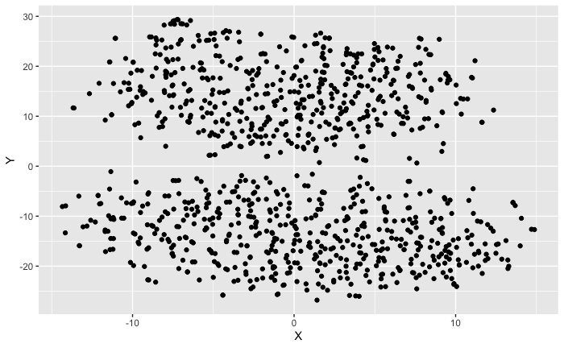

```r
set.seed(10)
tsne_converted_airway_val <- Rtsne(X = val_train_converted_airway,perplexity= 30, is_distance = FALSE, check_duplicates = FALSE)
tsne_converted_airway_val <- tsne_converted_airway_val$Y %>%
  data.frame() %>%
  setNames(c("X", "Y"))
ggplot(aes(x = X, y = Y), data = tsne_converted_airway_val)  + geom_point()
```

```
*** : The Hubert index is a graphical method of determining the number of clusters.
                In the plot of Hubert index, we seek a significant knee that corresponds to a
                significant increase of the value of the measure i.e the significant peak in Hubert
                index second differences plot.
```

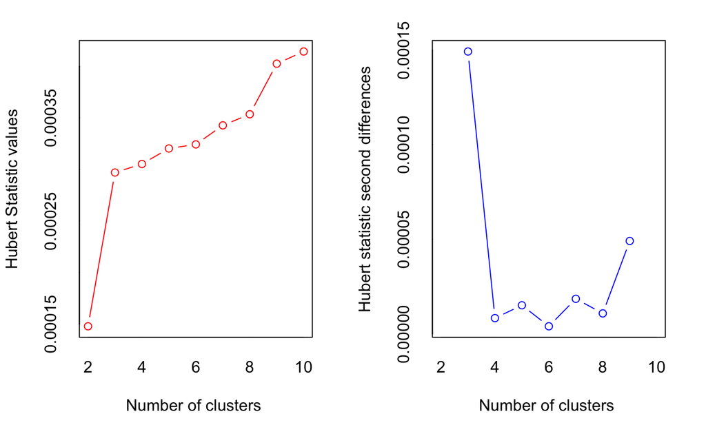

```
*** : The D index is a graphical method of determining the number of clusters.
                In the plot of D index, we seek a significant knee (the significant peak in Dindex
                second differences plot) that corresponds to a significant increase of the value of
                the measure.

* Among all indices:
* 6 proposed 2 as the best number of clusters
* 13 proposed 3 as the best number of clusters
* 1 proposed 4 as the best number of clusters
* 1 proposed 8 as the best number of clusters
* 1 proposed 9 as the best number of clusters
* 1 proposed 10 as the best number of clusters

                   ***** Conclusion *****

* According to the majority rule, the best number of clusters is  3
```

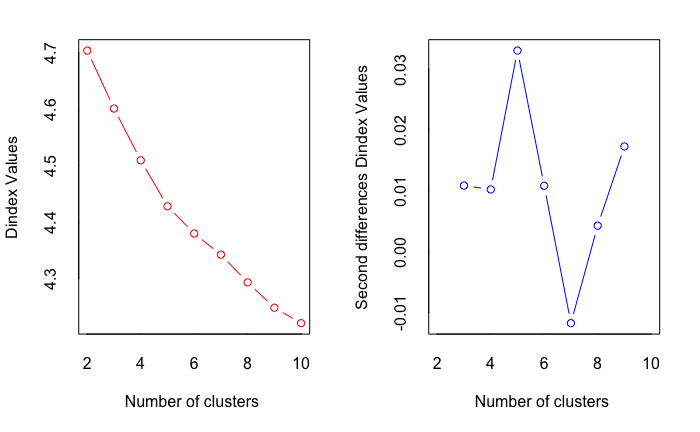

```r
library(NbClust)
Nb_converted_val_train <- NbClust(val_train_converted_airway, distance = "euclidean", min.nc = 2,
max.nc = 10, method = "kmeans")
```

```
Among all indices:
===================
* 2 proposed  0 as the best number of clusters
* 1 proposed  1 as the best number of clusters
* 6 proposed  2 as the best number of clusters
* 13 proposed  3 as the best number of clusters
* 1 proposed  4 as the best number of clusters
* 1 proposed  8 as the best number of clusters
* 1 proposed  9 as the best number of clusters
* 1 proposed  10 as the best number of clusters

Conclusion
=========================
* According to the majority rule, the best number of clusters is  3 .
```

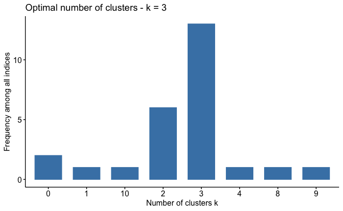

```r
fviz_nbclust(Nb_converted_val_train)
```

- Clustering with k-means

```r
set.seed(11)
k_converted_airway_val_train <- kmeans(val_train_converted_airway, centers = 6, nstart = 100)
grp_k_converted_val_train <- k_converted_airway_val_train$cluster
table(grp_k_converted_val_train)
```

```
grp_k_converted_val_train
  1   2   3   4   5   6
 11 340 115 122 222 196
```

- Adding the cluster to the data

```r
# copying the data
splited_train_airway_converted <- val_train_converted_airway
splited_train_airway_converted$clusters <- as.factor(grp_k_converted_val_train)
```

- second spliting of the data

```r
n_train <- round(0.8 * nrow(splited_train_airway_converted)) #80% of length of main data set as integer
train_indices <- sample(1:nrow(splited_train_airway_converted), n_train) #creating a vector with random indices
split_train <- splited_train_airway_converted[train_indices, ] #generating train data set (with ideces = train_indices)
split_train_test <- splited_train_airway_converted[-train_indices, ] #generating test data set
```

- Training the model on the train data of the second split ## RF-model

```r
# Create a Random Forest model with default parameters
SplitRF_model_airway <- randomForest(clusters ~ ., data = split_train, importance = TRUE)
SplitRF_model_airway
```

```
Call:
 randomForest(formula = clusters ~ ., data = split_train, importance = TRUE)
               Type of random forest: classification
                     Number of trees: 500
No. of variables tried at each split: 4

        OOB estimate of  error rate: 11.8%
Confusion matrix:
  1   2  3  4   5   6 class.error
1 0   0  3  4   3   0  1.00000000
2 0 270  0  0   0   5  0.01818182
3 0   0 71  4  20   0  0.25263158
4 0   0  2 84  13   0  0.15151515
5 0   0  3  9 160   0  0.06976744
6 0  28  0  0   1 125  0.18831169
```

```r
importance(SplitRF_model_airway, type = 1)
```

```
                         MeanDecreaseAccuracy
ever_smoker20py                     54.768041
exp_dust_work                       -1.271325
Longstanding_cough                   5.922480
Sputum_production                   13.971440
Chronic_productive_cough            14.954113
Recurrent_wheeze                    13.578890
asthmatic_wheeze                    16.841515
wheezeSB                             9.893515
dyspneaMRC                          93.182556
exacerbations                        1.850231
current_rhinitis                     8.065054
fam_asthma_allergy                   5.323070
fam_bronch_emphys                    3.036323
gender                               6.140095
IgEorSPT                             2.852892
Airway_medicine_use2                16.177733
F107                                30.554002
fev1pp_olin                         26.030797
fvcpp_olin                          17.503988
BMI                                  5.058620
post_fev1_fvc_ratio                 19.668972
delta_fev1                           2.266788
```

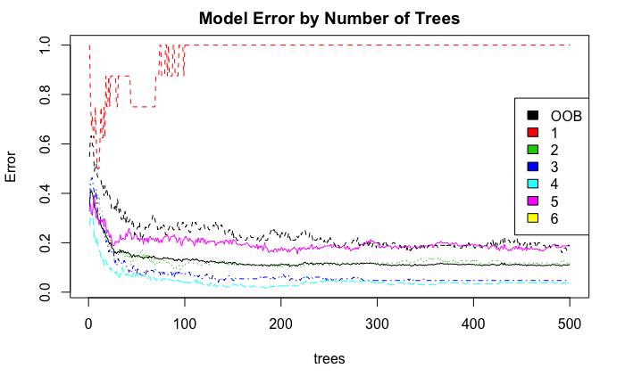

```r
plot(SplitRF_model_airway, main = "Model Error by Number of Trees")
legend(x = "right",
       legend = colnames(SplitRF_model_airway$err.rate),
       fill = 1:ncol(SplitRF_model_airway$err.rate))
```

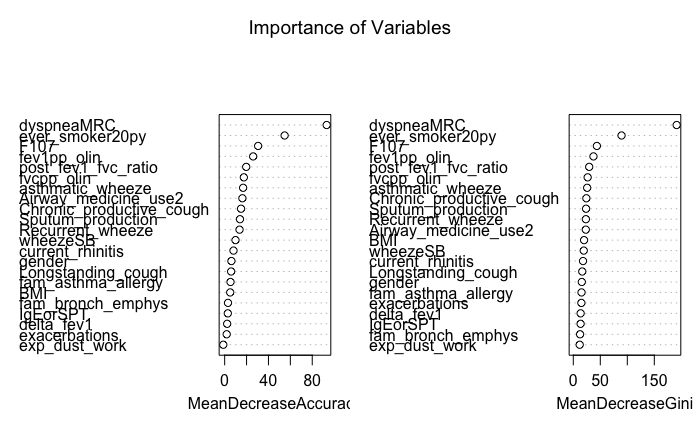

```r
varImpPlot(SplitRF_model_airway, main = "Importance of Variables") #plot variance importance
```

```r
# Predicting on Validation set
predValid <- predict(SplitRF_model_airway, split_train_test, type = "prob")
predValid_class <- predict(SplitRF_model_airway, split_train_test, type = "class")
confusionMatrix(data = predValid_class, reference = split_train_test$clusters)
```

```
Confusion Matrix and Statistics

          Reference
Prediction  1  2  3  4  5  6
         1  0  0  0  0  0  0
         2  0 64  0  0  0  7
         3  1  0 14  1  0  0
         4  0  0  1 20  0  0
         5  0  0  5  2 50  0
         6  0  1  0  0  0 35

Overall Statistics

               Accuracy : 0.9104
                 95% CI : (0.8622, 0.9461)
    No Information Rate : 0.3234
    P-Value [Acc > NIR] : < 2.2e-16

                  Kappa : 0.8818

 Mcnemar's Test P-Value : NA

Statistics by Class:

                     Class: 1 Class: 2 Class: 3 Class: 4 Class: 5 Class: 6
Sensitivity          0.000000   0.9846  0.70000   0.8696   1.0000   0.8333
Specificity          1.000000   0.9485  0.98895   0.9944   0.9536   0.9937
Pos Pred Value            NaN   0.9014  0.87500   0.9524   0.8772   0.9722
Neg Pred Value       0.995025   0.9923  0.96757   0.9833   1.0000   0.9576
Prevalence           0.004975   0.3234  0.09950   0.1144   0.2488   0.2090
Detection Rate       0.000000   0.3184  0.06965   0.0995   0.2488   0.1741
Detection Prevalence 0.000000   0.3532  0.07960   0.1045   0.2836   0.1791
Balanced Accuracy    0.500000   0.9666  0.84448   0.9320   0.9768   0.9135
```

- going to the orignal test data and apply UFT method then k-means clustering.

```r
val_test_airway_cate_to_num <- UFT_func(Data = val_test, Seed = 22)
val_test_airway_converted <- bined_converted_func(converted_data = val_test_airway_cate_to_num, original_data = val_test)
```

- Clustering the data using k-means

[figure not shown]

```r
Nb_converted_val_test <- NbClust(val_test_airway_converted, distance = "euclidean", min.nc = 2,
max.nc = 10, method = "kmeans")
fviz_nbclust(Nb_converted_val_test)
```

- Clustering with k-means

```r
#set.seed(11)
k_converted_airway_val_test <- kmeans(val_test_airway_converted, centers = 4, nstart = 100)
grp_k_converted_val_test <- k_converted_airway_val_test$cluster
table(grp_k_converted_val_test)
```

```
grp_k_converted_val_test
  1   2   3   4
109  50  78  14
```

```r
predValid_class_val <- predict(SplitRF_model_airway, val_test_airway_converted, type = "class")
adjustedRandIndex(predValid_class_val, grp_k_converted_val_test)
```

```
[1] 0.7909006
```

```r
extCriteria(as.integer(predValid_class_val), grp_k_converted_val_test, crit = "all")
```

```
$czekanowski_dice
[1] 0.862019

$folkes_mallows
[1] 0.8629199

$hubert
[1] 0.7928026

$jaccard
[1] 0.7574986

$kulczynski
[1] 0.8638216

$mcnemar
[1] 17.98498

$phi
[1] 3.589533e-09

$precision
[1] 0.9032827

$rand
[1] 0.9059442

$recall
[1] 0.8243606

$rogers_tanimoto
[1] 0.8280604

$russel_rao
[1] 0.2938008

$sokal_sneath1
[1] 0.6096561

$sokal_sneath2
[1] 0.9506513
```

# Another validation approach

- We run clustering on the data
- we split the data to two parts train and validation
- we split the train to two sets train and test
- we fit a model on the train data and test it on the test set
- we run the model on the validation part to predict the clusters
- we compare between the prediction and the labels
- Adding the cluster to the big main data ## UFT

```r
# copying the data
converted_airway_full <- converted_airway
converted_airway_full$clusters <- as.factor(grp_k_converted)
```

```r
n_train <- round(0.9 * nrow(converted_airway_full)) #80% of length of main data set as integer
train_indices <- sample(1:nrow(converted_airway_full), n_train) #creating a vector with random indices
split_train <- converted_airway_full[train_indices, ] #generating train data set (with ideces = train_indices)
split_validate <- converted_airway_full[-train_indices, ] #generating test data set
```

- Training the model on the train data of the second split

```r
n_train <- round(0.9 * nrow(split_train)) #80% of length of main data set as integer
train_indices <- sample(1:nrow(split_train), n_train) #creating a vector with random indices
split_train_train <- split_train[train_indices, ] #generating train data set (with ideces = train_indices)
split_train_test <- split_train[-train_indices, ] #generating test data set
```

```r
# Create a Random Forest model with default parameters
SplitRF_model_airway <- randomForest(clusters ~ ., data = split_train_train, importance = TRUE)
SplitRF_model_airway
```

```
Call:
 randomForest(formula = clusters ~ ., data = split_train_train,      importance = TRUE)
               Type of random forest: classification
                     Number of trees: 500
No. of variables tried at each split: 4

        OOB estimate of  error rate: 12.08%
Confusion matrix:
  1   2  3   4  5   6 class.error
1 0   0  6   3  4   0  1.00000000
2 0 348  0   0  0   4  0.01136364
3 0   0 79  24  5   0  0.26851852
4 0   0  1 229  3   0  0.01716738
5 0   1  1  35 82   1  0.31666667
6 0  35  0   0  0 157  0.18229167
```

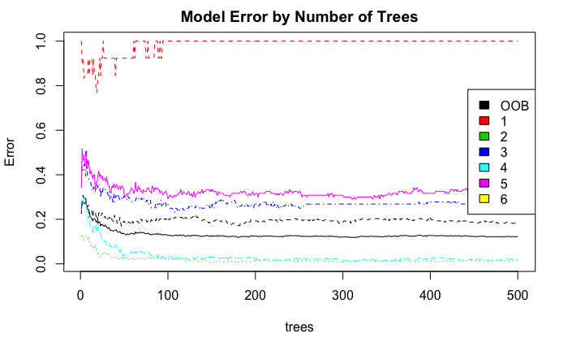

```r
plot(SplitRF_model_airway, main = "Model Error by Number of Trees")
legend(x = "right",
       legend = colnames(SplitRF_model_airway$err.rate),
       fill = 1:ncol(SplitRF_model_airway$err.rate))
```

```r
# Predicting on Validation set
predValid <- predict(SplitRF_model_airway, split_train_test, type = "prob")
predValid_class <- predict(SplitRF_model_airway, split_train_test, type = "class")
confusionMatrix(data = predValid_class, reference = split_train_test$clusters)
```

```
Confusion Matrix and Statistics

          Reference
Prediction  1  2  3  4  5  6
         1  1  0  0  0  0  0
         2  0 30  0  0  0  4
         3  0  0 14  0  0  0
         4  0  0  2 26  3  0
         5  0  0  0  0 16  0
         6  0  1  0  0  0 16

Overall Statistics

               Accuracy : 0.9115
                 95% CI : (0.8433, 0.9567)
    No Information Rate : 0.2743
    P-Value [Acc > NIR] : < 2.2e-16

                  Kappa : 0.8875

 Mcnemar's Test P-Value : NA

Statistics by Class:

                     Class: 1 Class: 2 Class: 3 Class: 4 Class: 5 Class: 6
Sensitivity           1.00000   0.9677   0.8750   1.0000   0.8421   0.8000
Specificity           1.00000   0.9512   1.0000   0.9425   1.0000   0.9892
Pos Pred Value        1.00000   0.8824   1.0000   0.8387   1.0000   0.9412
Neg Pred Value        1.00000   0.9873   0.9798   1.0000   0.9691   0.9583
Prevalence            0.00885   0.2743   0.1416   0.2301   0.1681   0.1770
Detection Rate        0.00885   0.2655   0.1239   0.2301   0.1416   0.1416
Detection Prevalence  0.00885   0.3009   0.1239   0.2743   0.1416   0.1504
Balanced Accuracy     1.00000   0.9595   0.9375   0.9713   0.9211   0.8946
```

```r
predValid_class_val <- predict(SplitRF_model_airway, split_validate %>% select(- clusters), type = "class")
#adjustedRandIndex(predValid_class_val, split_validate$clusters)
extCriteria(as.integer(predValid_class_val), as.integer(split_validate$clusters), crit = "all")
```

```
$czekanowski_dice
[1] 0.9061506

$folkes_mallows
[1] 0.9070942

$hubert
[1] 0.8782552

$jaccard
[1] 0.8284053

$kulczynski
[1] 0.9080387

$mcnemar
[1] 9.141697

$phi
[1] 7.784334e-08

$precision
[1] 0.9494445

$rand
[1] 0.9550476

$recall
[1] 0.8666329

$rogers_tanimoto
[1] 0.9139628

$russel_rao
[1] 0.2170159

$sokal_sneath1
[1] 0.7070749

$sokal_sneath2
[1] 0.977007
```

```r
ClusterPurity(predValid_class_val,split_validate$cluster)
```

```
[1] 0.9365079
```

## Dt

```r
# copying the data
Airway2_full <- Airway2
Airway2_full$clusters <- as.factor(h_tree$cluster)
```

```r
n_train <- round(0.9 * nrow(Airway2_full)) #80% of length of main data set as integer
train_indices <- sample(1:nrow(Airway2_full), n_train) #creating a vector with random indices
split_train <- Airway2_full[train_indices, ] #generating train data set (with ideces = train_indices)
split_validate <- Airway2_full[-train_indices, ] #generating test data set
```

- Training the model on the train data of the second split

```r
n_train <- round(0.9 * nrow(split_train)) #80% of length of main data set as integer
train_indices <- sample(1:nrow(split_train), n_train) #creating a vector with random indices
split_train_train <- split_train[train_indices, ] #generating train data set (with ideces = train_indices)
split_train_test <- split_train[-train_indices, ] #generating test data set
```

```r
# Create a Random Forest model with default parameters
SplitRF_model_airway_Dt <- randomForest(clusters ~ ., data = split_train_train, importance = TRUE)
SplitRF_model_airway_Dt
```

```
Call:
 randomForest(formula = clusters ~ ., data = split_train_train,      importance = TRUE)
               Type of random forest: classification
                     Number of trees: 500
No. of variables tried at each split: 4

        OOB estimate of  error rate: 9.14%
Confusion matrix:
   1   2   3   4   5  6 class.error
1 64   3   1   1   0  1 0.085714286
2  1 249  12   5  10  4 0.113879004
3  1   2 236   3   0  4 0.040650407
4  0   0   0 151   0  1 0.006578947
5  1  21   4   0 161  1 0.143617021
6  1   4   2  10   0 64 0.209876543
```

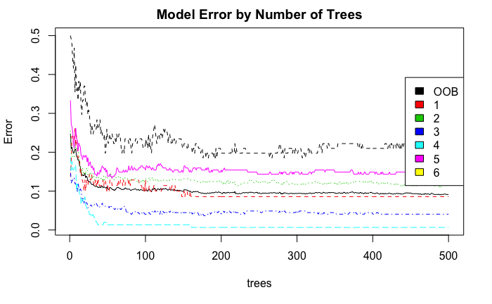

```r
plot(SplitRF_model_airway_Dt, main = "Model Error by Number of Trees")
legend(x = "right",
       legend = colnames(SplitRF_model_airway_Dt$err.rate),
       fill = 1:ncol(SplitRF_model_airway_Dt$err.rate))
```

```r
# Predicting on Validation set
predValid <- predict(SplitRF_model_airway_Dt, split_train_test, type = "prob")
predValid_class <- predict(SplitRF_model_airway_Dt, split_train_test, type = "class")
confusionMatrix(data = predValid_class, reference = split_train_test$clusters)
```

```
Confusion Matrix and Statistics

          Reference
Prediction  1  2  3  4  5  6
         1  9  0  0  0  0  0
         2  0 30  1  0  3  0
         3  0  2 32  0  0  0
         4  0  0  0 19  0  0
         5  0  1  0  0 13  0
         6  0  0  0  0  0  3

Overall Statistics

               Accuracy : 0.9381
                 95% CI : (0.8765, 0.9747)
    No Information Rate : 0.292
    P-Value [Acc > NIR] : < 2.2e-16

                  Kappa : 0.9197

 Mcnemar's Test P-Value : NA

Statistics by Class:

                     Class: 1 Class: 2 Class: 3 Class: 4 Class: 5 Class: 6
Sensitivity           1.00000   0.9091   0.9697   1.0000   0.8125  1.00000
Specificity           1.00000   0.9500   0.9750   1.0000   0.9897  1.00000
Pos Pred Value        1.00000   0.8824   0.9412   1.0000   0.9286  1.00000
Neg Pred Value        1.00000   0.9620   0.9873   1.0000   0.9697  1.00000
Prevalence            0.07965   0.2920   0.2920   0.1681   0.1416  0.02655
Detection Rate        0.07965   0.2655   0.2832   0.1681   0.1150  0.02655
Detection Prevalence  0.07965   0.3009   0.3009   0.1681   0.1239  0.02655
Balanced Accuracy     1.00000   0.9295   0.9723   1.0000   0.9011  1.00000
```

```r
predValid_class_val <- predict(SplitRF_model_airway_Dt, split_validate %>% select(- clusters), type = "class")
#adjustedRandIndex(predValid_class_val, split_validate$clusters)
extCriteria(as.integer(predValid_class_val), as.integer(split_validate$clusters), crit = "all")
```

```
$czekanowski_dice
[1] 0.8052583

$folkes_mallows
[1] 0.8052782

$hubert
[1] 0.7542455

$jaccard
[1] 0.6740021

$kulczynski
[1] 0.8052981

$mcnemar
[1] -0.9112931

$phi
[1] 7.391351e-08

$precision
[1] 0.7996357

$rand
[1] 0.9191111

$recall
[1] 0.8109606

$rogers_tanimoto
[1] 0.8503289

$russel_rao
[1] 0.1672381

$sokal_sneath1
[1] 0.508298

$sokal_sneath2
[1] 0.9578509
```

```r
ClusterPurity(predValid_class_val,split_validate$cluster)
```

```
[1] 0.9126984
```

## Deep learning DEC

```r
# copying the data
result_airway_uft_DEC_full <- read.csv('/Users/xbasra/Documents/Data/Airway_Clustering/Intermediate/CSV_output_data/result_airway_uft_DEC.csv')
result_airway_uft_DEC_full$cluster <- as.factor(result_airway_uft_DEC_full$cluster)
n_train <- round(0.9 * nrow(result_airway_uft_DEC_full)) #80% of length of main data set as integer
train_indices <- sample(1:nrow(result_airway_uft_DEC_full), n_train) #creating a vector with random indices
split_train <- result_airway_uft_DEC_full[train_indices, ] #generating train data set (with ideces = train_indices)
split_validate <- result_airway_uft_DEC_full[-train_indices, ] #generating test data set
```

- Training the model on the train data of the second split

```r
n_train <- round(0.9 * nrow(split_train)) #80% of length of main data set as integer
train_indices <- sample(1:nrow(split_train), n_train) #creating a vector with random indices
split_train_train <- split_train[train_indices, ] #generating train data set (with ideces = train_indices)
split_train_test <- split_train[-train_indices, ] #generating test data set
```

```r
# Create a Random Forest model with default parameters
SplitRF_model_airway_DEC <- randomForest(cluster ~ ., data = split_train_train, importance = TRUE)
SplitRF_model_airway_DEC
```

```
Call:
 randomForest(formula = cluster ~ ., data = split_train_train,      importance = TRUE)
               Type of random forest: classification
                     Number of trees: 500
No. of variables tried at each split: 4

        OOB estimate of  error rate: 0.2%
Confusion matrix:
    0   1   2   3  4   5 class.error
0 265   0   0   0  0   0  0.00000000
1   0 264   0   0  0   0  0.00000000
2   0   0 138   0  0   0  0.00000000
3   0   0   0 169  0   0  0.00000000
4   0   0   0   2 49   0  0.03921569
5   0   0   0   0  0 131  0.00000000
```

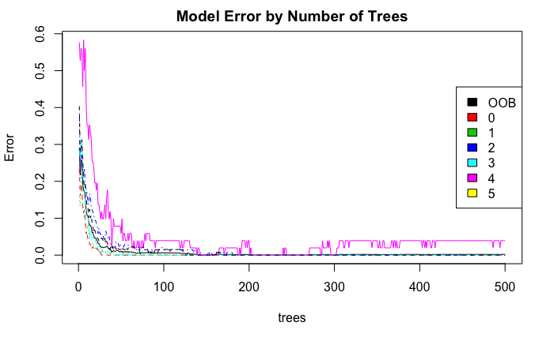

```r
plot(SplitRF_model_airway_DEC, main = "Model Error by Number of Trees")
legend(x = "right",
       legend = colnames(SplitRF_model_airway_DEC$err.rate),
       fill = 1:ncol(SplitRF_model_airway_DEC$err.rate))
```

```r
# Predicting on Validation set
predValid <- predict(SplitRF_model_airway_DEC, split_train_test, type = "prob")
predValid_class <- predict(SplitRF_model_airway_DEC, split_train_test, type = "class")
confusionMatrix(data = predValid_class, reference = split_train_test$cluster)
```

```
Confusion Matrix and Statistics

          Reference
Prediction  0  1  2  3  4  5
         0 23  0  0  0  0  0
         1  0 29  1  0  0  0
         2  0  0 14  0  0  0
         3  0  0  0 22  1  0
         4  0  0  0  0  7  0
         5  0  0  0  0  0 16

Overall Statistics

               Accuracy : 0.9823
                 95% CI : (0.9375, 0.9978)
    No Information Rate : 0.2566
    P-Value [Acc > NIR] : < 2.2e-16

                  Kappa : 0.9781

 Mcnemar's Test P-Value : NA

Statistics by Class:

                     Class: 0 Class: 1 Class: 2 Class: 3 Class: 4 Class: 5
Sensitivity            1.0000   1.0000   0.9333   1.0000  0.87500   1.0000
Specificity            1.0000   0.9881   1.0000   0.9890  1.00000   1.0000
Pos Pred Value         1.0000   0.9667   1.0000   0.9565  1.00000   1.0000
Neg Pred Value         1.0000   1.0000   0.9899   1.0000  0.99057   1.0000
Prevalence             0.2035   0.2566   0.1327   0.1947  0.07080   0.1416
Detection Rate         0.2035   0.2566   0.1239   0.1947  0.06195   0.1416
Detection Prevalence   0.2035   0.2655   0.1239   0.2035  0.06195   0.1416
Balanced Accuracy      1.0000   0.9940   0.9667   0.9945  0.93750   1.0000
```

```r
predValid_class_val <- predict(SplitRF_model_airway_DEC, split_validate %>% select(- cluster), type = "class")
#adjustedRandIndex(predValid_class_val, split_validate$cluster)
extCriteria(as.integer(predValid_class_val), as.integer(split_validate$cluster), crit = "all")
```

```
$czekanowski_dice
[1] 0.9827838

$folkes_mallows
[1] 0.9827908

$hubert
[1] 0.9780076

$jaccard
[1] 0.9661503

$kulczynski
[1] 0.9827979

$mcnemar
[1] -1.692456

$phi
[1] 9.263498e-08

$precision
[1] 0.9790698

$rand
[1] 0.9925079

$recall
[1] 0.9865261

$rogers_tanimoto
[1] 0.9851273

$russel_rao
[1] 0.2138413

$sokal_sneath1
[1] 0.9345172

$sokal_sneath2
[1] 0.9962399
```

```r
ClusterPurity(predValid_class_val,split_validate$cluster)
```

```
[1] 0.984127
```